# Machine Learning Project, Coursera

aimod62

November 15, 2016

The goal of the present assignment is to provide a machine learning algorithm capable of predicting the manner in which the population perform selected lifting routines. Data is drawn from 6 male participants aged between 20-28 years. The categorical variable **classe** is our response variable. Out of its 5 levels: classe **A** represents a well done execution. The remaining four levels: **B, C, D, E** portray minor failures.

A typical classification problem of supervised learning.

## 0.1 Loading Required Libraries

```r
library(caret)
library(ranger)
library(foreach)
library(e1071)
library(rpart)
library(C50)
library(kernlab)
library(MASS)
library(klaR)
library(ipred)
library(plyr)
```

## 0.2 Loading the Data

Two sets of data have been provided by the assignment prompt:

Training set: 19622 Observations and 160 Variables

Testing set: 20 Observations and 160 Variables

As expected, the test set would be brought out only at the end of the submission in order to assess the generalization error, and corroborate its accuracy by means of the mandatory quiz.

```r
pml.training <- read.csv("C:/Users/AstridIleana/Desktop/Machine Learning/Project/pml-training.csv", stringsAsFactors=FALSE)
pml.testing <- read.csv("C:/Users/AstridIleana/Desktop/Machine Learning/Project/pml-testing.csv", stringsAsFactors= FALSE)
```

## 0.3 Data Partition

The given training data set has been further partitioned in a validation data set. A highly recommendable practice meant to estimate the prediction error of the model.

```r
set.seed(1028)
inTrain <- createDataPartition(y = pml.training$classe, # Outcome Data
                               p = 0.75,                # Data percentage in the training set.
                               list = FALSE)            # Results format

#Creating the training and validation set

training <- pml.training[inTrain, ]
validation <- pml.training[-inTrain, ]
dim(training); dim(validation)
```

```
[1] 14718   160
```

```
[1] 4904  160
```

```r
table(as.factor(training$classe))
```

```
   A    B    C    D    E
4185 2848 2567 2412 2706
```

```r
table(as.factor(validation$classe))
```

```
   A    B    C    D    E
1395  949  855  804  901
```

## 0.4 Removing Irrelevant and Redundant Information

A subset of the training data has been created. Two features have been removed: near zero variances variables and NA values. The idea is to clear as much redundant and irrelevant data as possible; in order to reduce the dimensionality and allow the algorithm to operate faster and more accurate.

```r
#Getting rid of near zero variance predictors and NA values
remove <- nearZeroVar(training, names = TRUE, allowParallel = TRUE)
trainingAdjusted <- training[, setdiff(names(training), remove)]
trainingAdjusted <- trainingAdjusted[, colSums(is.na(trainingAdjusted)) == 0]
dim(trainingAdjusted)
```

```
[1] 14718    59
```

## 0.5 Trial and Error, in Search of the Best Fit

Since there is no clue of the data distribution until now, an ensemble of models have been chosen from the wide spectrum to look for the best fit. The idea is to use few of them, and evolve further.

*Non-linear Methods: knn, NaiveBayes, SVM

*Linear Methods: Linear Discriminant Analysis

*Ensemble of Trees: CART(rpart)

Trees and Rules: C50, BaggedCART, ranger

2.Cross-Validation, probably the simplest and most widely used method, has been selected for estimating the prediction error.

2.ranger(ranger package) has been favored over the popular randomForest due to its easier fit.

```r
#Creating uniform parameters
seed <- set.seed(2810) # Create uniform conditions for comparison's purposes.
control <- trainControl(method = "cv",
                        number = 5)
metric <- "Accuracy"

## Constructing several models
set.seed(seed)
rangerFit<- train(classe~.,
                  data = trainingAdjusted,
                  method = "ranger",
                  metric = metric,
                  trControl = control)


set.seed(seed)
knnFit <- train(classe ~.,
                data = trainingAdjusted,
                method = "knn",
                trControl = control,
                metric = metric,
                preProcess = c("center", "scale")) # Mandatory centering and Scaling

set.seed(seed)
rpartFit <- train(classe ~.,
                  data= trainingAdjusted,
                  method = "rpart",
                  metric = metric,
                  trControl = control)

set.seed(seed)
C5.0Fit <- train(classe ~.,
                 data= trainingAdjusted,
                 method = "C5.0",
                 metric = metric,
                 trControl = control)

set.seed(seed)
bagFit <-train(classe ~.,
               data= trainingAdjusted,
               method = "treebag",
               metric = metric,
               trControl = control)

set.seed(seed)
svmRadialFit <-train(classe ~.,
               data= trainingAdjusted,
               method = "svmRadial",
               metric = metric,
               trControl = control,
               preProcess = c("nzv", "center", "scale"),
               fit = FALSE)

set.seed(seed)
ldaFit <-train(classe ~.,
               data= trainingAdjusted,
               method = "lda",
               metric = metric,
               trControl = control,
               preProcess = "pca") #scaling by design

set.seed(seed)
nbFit <-train(classe ~.,
               data= trainingAdjusted,
               method = "nb",
               metric = metric,
               trControl = control) #scaling by design

#Comparing the different models
model_results <- resamples(list(Ranger = rangerFit, knn = knnFit, CART = rpartFit, C5.0 = C5.0Fit,  baggedCART = bagFit, svmRadial = svmRadialFit,
                                lda = ldaFit, NaiveBayes = nbFit))
summary(model_results)
```

```
Call:
summary.resamples(object = model_results)

Models: Ranger, knn, CART, C5.0, baggedCART, svmRadial, lda, NaiveBayes
Number of resamples: 5

Accuracy
             Min. 1st Qu. Median   Mean 3rd Qu.   Max. NA's
Ranger     0.9997  0.9997 0.9997 0.9997  0.9997 1.0000    0
knn        0.9728  0.9745 0.9759 0.9768  0.9800 0.9806    0
CART       0.6613  0.6613 0.8359 0.7661  0.8359 0.8362    0
C5.0       0.9993  0.9997 0.9997 0.9997  1.0000 1.0000    0
baggedCART 0.9997  1.0000 1.0000 0.9999  1.0000 1.0000    0
svmRadial  0.9854  0.9861 0.9864 0.9876  0.9888 0.9912    0
lda        0.8230  0.8281 0.8305 0.8342  0.8417 0.8478    0
NaiveBayes 0.8590  0.8631 0.8635 0.8734  0.8753 0.9062    0

Kappa
             Min. 1st Qu. Median   Mean 3rd Qu.   Max. NA's
Ranger     0.9996  0.9996 0.9996 0.9997  0.9996 1.0000    0
knn        0.9656  0.9678 0.9695 0.9706  0.9746 0.9755    0
CART       0.5690  0.5690 0.7920 0.7029  0.7921 0.7924    0
C5.0       0.9991  0.9996 0.9996 0.9997  1.0000 1.0000    0
baggedCART 0.9996  1.0000 1.0000 0.9999  1.0000 1.0000    0
svmRadial  0.9815  0.9824 0.9828 0.9843  0.9858 0.9888    0
lda        0.7766  0.7830 0.7859 0.7907  0.7999 0.8079    0
NaiveBayes 0.8193  0.8246 0.8249 0.8380  0.8405 0.8806    0
```

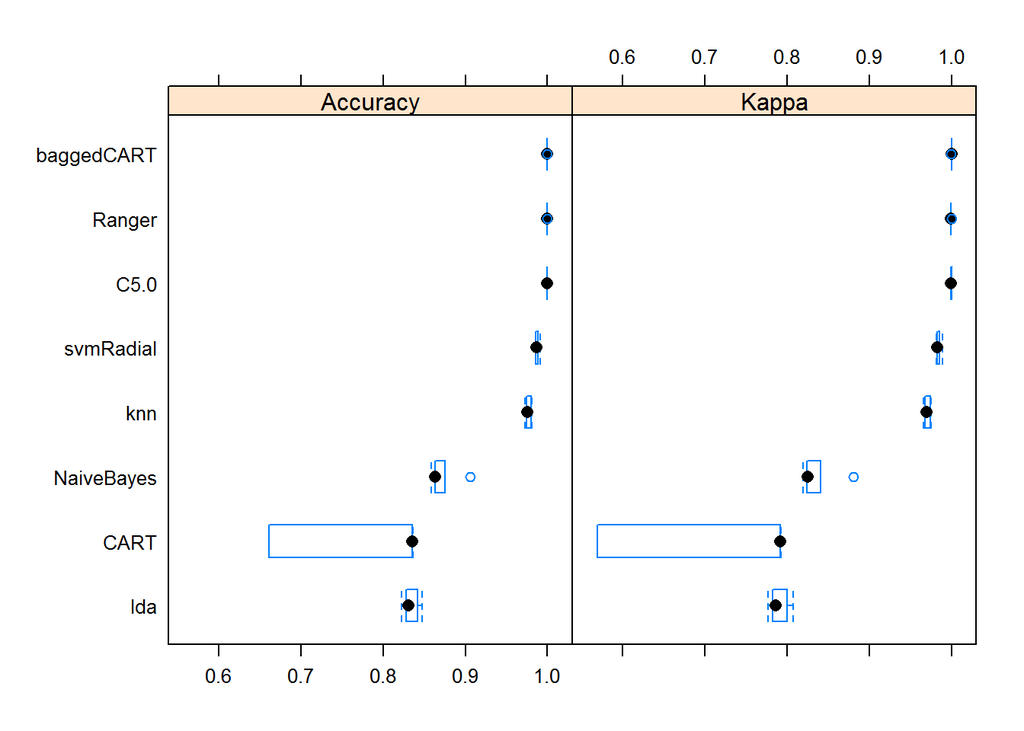

```r
bwplot(model_results)
```

Clearly, the linear model does not perform well.However, as indicated by the previous plot, C5.0Fit, baggedCART fit and rangerFit are worth to be investigated further.

## 0.6 Improving the model

```r
#Customazing trainControl
myControl<- trainControl(method = "cv",
                            number = 5,
                            repeats = 3,
                            summaryFunction = defaultSummary,
                            classProbs = TRUE,
                            verboseIter = TRUE)
#Comparing rangerFit

set.seed(seed)
rangerFit.1 <- train(classe~.,
                     data = trainingAdjusted,
                     method = "ranger",
                     trControl = myControl)

set.seed(seed)
rangerFit.PCA <- train(classe~.,
                       data = trainingAdjusted,
                       method = "ranger",
                       trControl = myControl,
                       preProcess = "pca")
set.seed(seed)
rangerFit.mtry <- train(classe~.,
                        data = trainingAdjusted,
                        method = "ranger",
                        tuneGrid = data.frame(mtry = 7),
                        trControl = myControl)
```

```r
# Assessing the results
ranger_results <- resamples(list(model1 = rangerFit, model2 = rangerFit.1, model3 =rangerFit.PCA, model4 = rangerFit.mtry))
summary(ranger_results)
```

```
Call:
summary.resamples(object = ranger_results)

Models: model1, model2, model3, model4
Number of resamples: 5

Accuracy
         Min. 1st Qu. Median   Mean 3rd Qu.   Max. NA's
model1 0.9997  0.9997 0.9997 0.9997  0.9997 1.0000    0
model2 0.9986  0.9997 0.9997 0.9996  1.0000 1.0000    0
model3 0.9793  0.9806 0.9810 0.9810  0.9813 0.9827    0
model4 0.9997  0.9997 1.0000 0.9999  1.0000 1.0000    0

Kappa
         Min. 1st Qu. Median   Mean 3rd Qu.   Max. NA's
model1 0.9996  0.9996 0.9996 0.9997  0.9996 1.0000    0
model2 0.9983  0.9996 0.9996 0.9995  1.0000 1.0000    0
model3 0.9738  0.9755 0.9759 0.9759  0.9764 0.9781    0
model4 0.9996  0.9996 1.0000 0.9998  1.0000 1.0000    0
```

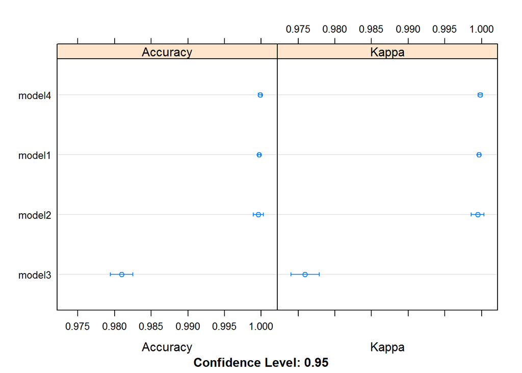

```r
dotplot(ranger_results)
```

```r
#Improving the C5.0Fit
set.seed(seed)
C5.0Fit.1 <- train(classe ~.,
                 data= trainingAdjusted,
                 method = "C5.0Tree",
                 metric = metric,
                 trControl = control)

C5_results <- resamples(list(model1 = C5.0Fit, model2 = C5.0Fit.1))
summary(C5_results)
```

```
##
## Call:
## summary.resamples(object = C5_results)
##
## Models: model1, model2
## Number of resamples: 5
##
## Accuracy
##          Min. 1st Qu. Median   Mean 3rd Qu. Max. NA's
## model1 0.9993  0.9997 0.9997 0.9997  1.0000    1    0
## model2 0.9997  0.9997 0.9997 0.9997  0.9997    1    0
##
## Kappa
##          Min. 1st Qu. Median   Mean 3rd Qu. Max. NA's
## model1 0.9991  0.9996 0.9996 0.9997  1.0000    1    0
## model2 0.9996  0.9996 0.9996 0.9997  0.9996    1    0
```

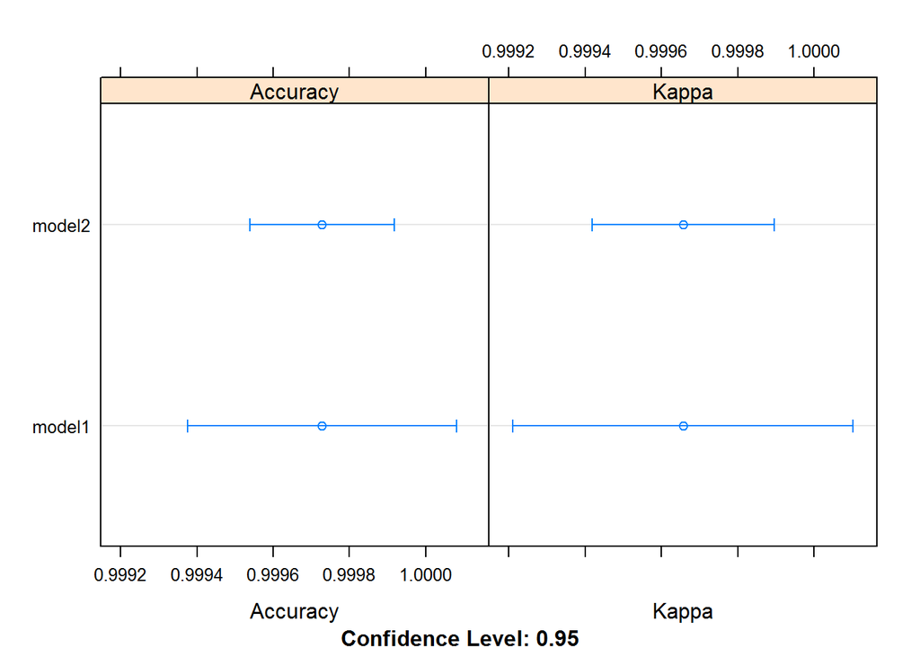

```r
dotplot(C5_results)
```

C5.0Fit is replaced by C5.0Fit.1

## 0.7 Selecting the Model

A conundrum between the first and the second model, Do I favor higher accuracy, but higher variance, or less variance, but less accuracy?

```r
final_results <- resamples(list(modelRanger = rangerFit.mtry, modelBaggedCART = bagFit, modelC5Tree = C5.0Fit.1))
summary(final_results)
```

```
Call:
summary.resamples(object = final_results)

Models: modelRanger, modelBaggedCART, modelC5Tree
Number of resamples: 5

Accuracy
                  Min. 1st Qu. Median   Mean 3rd Qu. Max. NA's
modelRanger     0.9997  0.9997 1.0000 0.9999  1.0000    1    0
modelBaggedCART 0.9997  1.0000 1.0000 0.9999  1.0000    1    0
modelC5Tree     0.9997  0.9997 0.9997 0.9997  0.9997    1    0

Kappa
                  Min. 1st Qu. Median   Mean 3rd Qu. Max. NA's
modelRanger     0.9996  0.9996 1.0000 0.9998  1.0000    1    0
modelBaggedCART 0.9996  1.0000 1.0000 0.9999  1.0000    1    0
modelC5Tree     0.9996  0.9996 0.9996 0.9997  0.9996    1    0
```

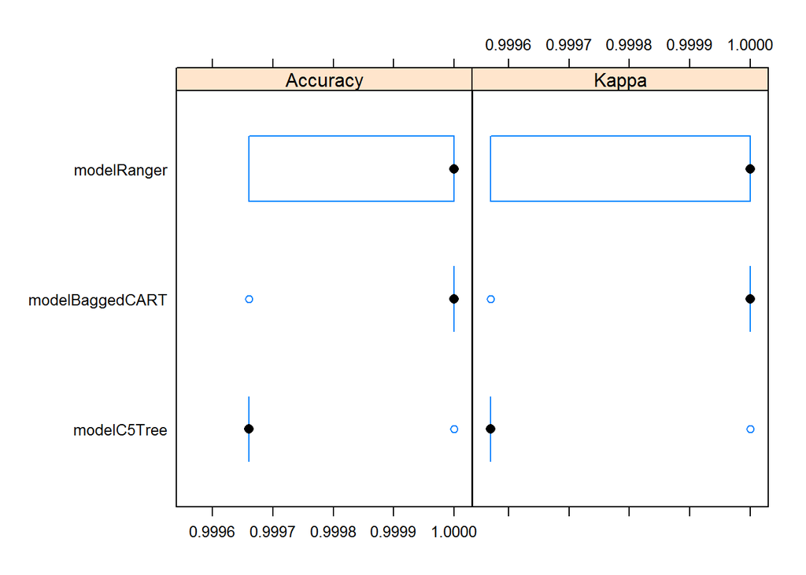

```r
bwplot(final_results)
```

## 0.8 Predicting on the Validation Test

```r
#Remove the seed.
ranger_final <- train(classe~.,
                      data = trainingAdjusted,
                      method = "ranger",
                      tuneGrid = data.frame(mtry = 3),
                      trControl = myControl)
```

```r
# Validation set
rangerPredict<- predict(ranger_final, validation)
confusionMatrix(rangerPredict, validation$classe)
```

```
Confusion Matrix and Statistics

          Reference
Prediction    A    B    C    D    E
         A 1394    0    0    0    0
         B    1  949    0    0    0
         C    0    0  855    0    0
         D    0    0    0  803    0
         E    0    0    0    1  901

Overall Statistics

               Accuracy : 0.9996
                 95% CI : (0.9985, 1)
    No Information Rate : 0.2845
    P-Value [Acc > NIR] : < 2.2e-16

                  Kappa : 0.9995
 Mcnemar's Test P-Value : NA

Statistics by Class:

                     Class: A Class: B Class: C Class: D Class: E
Sensitivity            0.9993   1.0000   1.0000   0.9988   1.0000
Specificity            1.0000   0.9997   1.0000   1.0000   0.9998
Pos Pred Value         1.0000   0.9989   1.0000   1.0000   0.9989
Neg Pred Value         0.9997   1.0000   1.0000   0.9998   1.0000
Prevalence             0.2845   0.1935   0.1743   0.1639   0.1837
Detection Rate         0.2843   0.1935   0.1743   0.1637   0.1837
Detection Prevalence   0.2843   0.1937   0.1743   0.1637   0.1839
Balanced Accuracy      0.9996   0.9999   1.0000   0.9994   0.9999
```

```r
#plot
```

## 0.9 Predicting on the testing set. Quiz

However, it is important to mention that the original **mtry** = 7 (number of variables possible to split in each node) was changed to 3. Using the former parameter, a 8/20 ratio of correct answers was obtained; the latter produced a 20/20 ratio.

```r
predict(ranger_final, pml.testing )
```

```
 [1] B A B A A E D B A A B C B A E E A B B B
Levels: A B C D E
```

## 0.10 Conclusion

The main remark to my first approach to the fascinating science of Machine Learning is the way the NA values were handled; simply omitting them without further ado. A knn imputation had been more fruitful.

## 0.11 Data Source

Ugulino, W.; Cardador, D.; Vega, K.; Velloso, E.; Milidiu, R.; Fuks, H. Wearable Computing: Accelerometers’ Data Classification of Body Postures and Movements. Proceedings of 21st Brazilian Symposium on Artificial Intelligence. Advances in Artificial Intelligence - SBIA 2012. In: Lecture Notes in Computer Science. , pp. 52-61. Curitiba, PR: Springer Berlin / Heidelberg, 2012. =======